# Project: Investigate a DataSet[no-show-appointment]

- Introduction
- Data Wrangling
- Exploratory Data Analysis
- Conclusions

# Do all patient show up for there appointment?

**This dataset collects information from 100k medical appointments in Brazil**  
Depending on number of factors ( which I'll discuss later), Which one of them is important for us to know in order to predict if a patient will show up for their scheduled appointment?

### Question(s) for Analysis

> **How many people show up in the appointment day?**

> **Does SMS messeges affect the count of people showing up? and how?**

> **Who append most? Male or Female?**

> **Do Hypertensive patients append more than non-hypertensive?**

> **How can age affect the data?**

```python
# Let's import packa
import pandas as pd
import numpy as np
import matplotlib.pylab as plt
import seaborn as sns
from matplotlib import figure
%matplotlib inline
plt.style.use('fivethirtyeight')
```

```python
# Upgrade pandas to use dataframe.explode() function.
!pip install --upgrade pandas==0.25.0
```

[output not shown]

## Data Wrangling

#### Let's download our data

```python
df=pd.read_csv('noshowappointments-kagglev2-may-2016.csv')
df.head(10)
```

|  | PatientId | AppointmentID | Gender | ScheduledDay | AppointmentDay | Age | Neighbourhood | Scholarship | Hipertension | Diabetes | Alcoholism | Handcap | SMS_received | No-show |
| --- | --- | --- | --- | --- | --- | --- | --- | --- | --- | --- | --- | --- | --- | --- |
| 0 | 2.987250e+13 | 5642903 | F | 2016-04-29T18:38:08Z | 2016-04-29T00:00:00Z | 62 | JARDIM DA PENHA | 0 | 1 | 0 | 0 | 0 | 0 | No |
| 1 | 5.589978e+14 | 5642503 | M | 2016-04-29T16:08:27Z | 2016-04-29T00:00:00Z | 56 | JARDIM DA PENHA | 0 | 0 | 0 | 0 | 0 | 0 | No |
| 2 | 4.262962e+12 | 5642549 | F | 2016-04-29T16:19:04Z | 2016-04-29T00:00:00Z | 62 | MATA DA PRAIA | 0 | 0 | 0 | 0 | 0 | 0 | No |
| 3 | 8.679512e+11 | 5642828 | F | 2016-04-29T17:29:31Z | 2016-04-29T00:00:00Z | 8 | PONTAL DE CAMBURI | 0 | 0 | 0 | 0 | 0 | 0 | No |
| 4 | 8.841186e+12 | 5642494 | F | 2016-04-29T16:07:23Z | 2016-04-29T00:00:00Z | 56 | JARDIM DA PENHA | 0 | 1 | 1 | 0 | 0 | 0 | No |
| 5 | 9.598513e+13 | 5626772 | F | 2016-04-27T08:36:51Z | 2016-04-29T00:00:00Z | 76 | REPÚBLICA | 0 | 1 | 0 | 0 | 0 | 0 | No |
| 6 | 7.336882e+14 | 5630279 | F | 2016-04-27T15:05:12Z | 2016-04-29T00:00:00Z | 23 | GOIABEIRAS | 0 | 0 | 0 | 0 | 0 | 0 | Yes |
| 7 | 3.449833e+12 | 5630575 | F | 2016-04-27T15:39:58Z | 2016-04-29T00:00:00Z | 39 | GOIABEIRAS | 0 | 0 | 0 | 0 | 0 | 0 | Yes |
| 8 | 5.639473e+13 | 5638447 | F | 2016-04-29T08:02:16Z | 2016-04-29T00:00:00Z | 21 | ANDORINHAS | 0 | 0 | 0 | 0 | 0 | 0 | No |
| 9 | 7.812456e+13 | 5629123 | F | 2016-04-27T12:48:25Z | 2016-04-29T00:00:00Z | 19 | CONQUISTA | 0 | 0 | 0 | 0 | 0 | 0 | No |

```python
df.info()
```

```
<class 'pandas.core.frame.DataFrame'>
RangeIndex: 110527 entries, 0 to 110526
Data columns (total 14 columns):
PatientId         110527 non-null float64
AppointmentID     110527 non-null int64
Gender            110527 non-null object
ScheduledDay      110527 non-null object
AppointmentDay    110527 non-null object
Age               110527 non-null int64
Neighbourhood     110527 non-null object
Scholarship       110527 non-null int64
Hipertension      110527 non-null int64
Diabetes          110527 non-null int64
Alcoholism        110527 non-null int64
Handcap           110527 non-null int64
SMS_received      110527 non-null int64
No-show           110527 non-null object
dtypes: float64(1), int64(8), object(5)
memory usage: 11.8+ MB
```

```python
df.describe()
```

|  | PatientId | AppointmentID | Age | Scholarship | Hipertension | Diabetes | Alcoholism | Handcap | SMS_received |
| --- | --- | --- | --- | --- | --- | --- | --- | --- | --- |
| count | 1.105270e+05 | 1.105270e+05 | 110527.000000 | 110527.000000 | 110527.000000 | 110527.000000 | 110527.000000 | 110527.000000 | 110527.000000 |
| mean | 1.474963e+14 | 5.675305e+06 | 37.088874 | 0.098266 | 0.197246 | 0.071865 | 0.030400 | 0.022248 | 0.321026 |
| std | 2.560949e+14 | 7.129575e+04 | 23.110205 | 0.297675 | 0.397921 | 0.258265 | 0.171686 | 0.161543 | 0.466873 |
| min | 3.921784e+04 | 5.030230e+06 | -1.000000 | 0.000000 | 0.000000 | 0.000000 | 0.000000 | 0.000000 | 0.000000 |
| 25% | 4.172614e+12 | 5.640286e+06 | 18.000000 | 0.000000 | 0.000000 | 0.000000 | 0.000000 | 0.000000 | 0.000000 |
| 50% | 3.173184e+13 | 5.680573e+06 | 37.000000 | 0.000000 | 0.000000 | 0.000000 | 0.000000 | 0.000000 | 0.000000 |
| 75% | 9.439172e+13 | 5.725524e+06 | 55.000000 | 0.000000 | 0.000000 | 0.000000 | 0.000000 | 0.000000 | 1.000000 |
| max | 9.999816e+14 | 5.790484e+06 | 115.000000 | 1.000000 | 1.000000 | 1.000000 | 1.000000 | 4.000000 | 1.000000 |

```python
df.duplicated().sum()
```

```
0
```

```python
df.isnull().sum().sum()
```

```
0
```

```python
df.shape
```

```
(110527, 14)
```

#### *What I have Obeserved*: That there is no null values nor duplicated rows

### Data Cleaning

#### I want to convert the type of appointmentid and patientid into string type

```python
df['AppointmentID']=df['AppointmentID'].astype(str)
df['PatientId']=df['PatientId'].astype(str)
```

```python
df.describe()
```

|  | Age | Scholarship | Hipertension | Diabetes | Alcoholism | Handcap | SMS_received |
| --- | --- | --- | --- | --- | --- | --- | --- |
| count | 110527.000000 | 110527.000000 | 110527.000000 | 110527.000000 | 110527.000000 | 110527.000000 | 110527.000000 |
| mean | 37.088874 | 0.098266 | 0.197246 | 0.071865 | 0.030400 | 0.022248 | 0.321026 |
| std | 23.110205 | 0.297675 | 0.397921 | 0.258265 | 0.171686 | 0.161543 | 0.466873 |
| min | -1.000000 | 0.000000 | 0.000000 | 0.000000 | 0.000000 | 0.000000 | 0.000000 |
| 25% | 18.000000 | 0.000000 | 0.000000 | 0.000000 | 0.000000 | 0.000000 | 0.000000 |
| 50% | 37.000000 | 0.000000 | 0.000000 | 0.000000 | 0.000000 | 0.000000 | 0.000000 |
| 75% | 55.000000 | 0.000000 | 0.000000 | 0.000000 | 0.000000 | 0.000000 | 1.000000 |
| max | 115.000000 | 1.000000 | 1.000000 | 1.000000 | 1.000000 | 4.000000 | 1.000000 |

```python
df.describe(include='O')
```

|  | PatientId | AppointmentID | Gender | ScheduledDay | AppointmentDay | Neighbourhood | No-show |
| --- | --- | --- | --- | --- | --- | --- | --- |
| count | 110527 | 110527 | 110527 | 110527 | 110527 | 110527 | 110527 |
| unique | 62299 | 110527 | 2 | 103549 | 27 | 81 | 2 |
| top | 8.22145925426e+14 | 5708459 | F | 2016-05-06T07:09:54Z | 2016-06-06T00:00:00Z | JARDIM CAMBURI | No |
| freq | 88 | 1 | 71840 | 24 | 4692 | 7717 | 88208 |

#### Now That's great! in AppointmentId column : unique and count are equal, so it's better to be dropped, as it's useless

### Drop unnecessary columns

```python
df.drop(['AppointmentID'],axis=1,inplace=True)
```

```python
df.columns
```

```
Index(['PatientId', 'Gender', 'ScheduledDay', 'AppointmentDay', 'Age',
       'Neighbourhood', 'Scholarship', 'Hipertension', 'Diabetes',
       'Alcoholism', 'Handcap', 'SMS_received', 'No-show'],
      dtype='object')
```

### There is something wrong with the age column : as age of 0 or -1 is not acceptable

```python
df.drop(df[df['Age']<0].index,inplace=True)
```

```python
df.describe()
```

|  | Age | Scholarship | Hipertension | Diabetes | Alcoholism | Handcap | SMS_received |
| --- | --- | --- | --- | --- | --- | --- | --- |
| count | 110526.000000 | 110526.000000 | 110526.000000 | 110526.000000 | 110526.000000 | 110526.000000 | 110526.000000 |
| mean | 37.089219 | 0.098266 | 0.197248 | 0.071865 | 0.030400 | 0.022248 | 0.321029 |
| std | 23.110026 | 0.297676 | 0.397923 | 0.258266 | 0.171686 | 0.161543 | 0.466874 |
| min | 0.000000 | 0.000000 | 0.000000 | 0.000000 | 0.000000 | 0.000000 | 0.000000 |
| 25% | 18.000000 | 0.000000 | 0.000000 | 0.000000 | 0.000000 | 0.000000 | 0.000000 |
| 50% | 37.000000 | 0.000000 | 0.000000 | 0.000000 | 0.000000 | 0.000000 | 0.000000 |
| 75% | 55.000000 | 0.000000 | 0.000000 | 0.000000 | 0.000000 | 0.000000 | 1.000000 |
| max | 115.000000 | 1.000000 | 1.000000 | 1.000000 | 1.000000 | 4.000000 | 1.000000 |

#### I'll make columns in lowercase.

```python
df.rename(columns=lambda x: x.lower(),inplace=True)
```

```python
df.columns
```

```
Index(['patientid', 'gender', 'scheduledday', 'appointmentday', 'age',
       'neighbourhood', 'scholarship', 'hipertension', 'diabetes',
       'alcoholism', 'handcap', 'sms_received', 'no-show'],
      dtype='object')
```

#### Correct the mislabel in (hipertension)

```python
df.rename(columns={'hipertension':'hypertension'}, inplace=True)
```

#### Correct the mislabel in (handcap)

```python
df.rename(columns={'handcap':'handicap'},inplace=True)
```

#### handle some column labels

```python
df.rename(columns={'patientid':'patient_id','scheduledday':'sched_day','appointmentday':'app_day','no-show':'show'},inplace=True)
```

```python
df.columns
```

```
Index(['patient_id', 'gender', 'sched_day', 'app_day', 'age', 'neighbourhood',
       'scholarship', 'hypertension', 'diabetes', 'alcoholism', 'handicap',
       'sms_received', 'show'],
      dtype='object')
```

#### let's convert schedule_day and appointmen_day into to date time

```python
df['sched_day']=pd.to_datetime(df['sched_day'])
df['app_day']=pd.to_datetime(df['app_day'])
```

I want to extract month, hour and day of week:

```python
df['sched_month']=df['sched_day'].dt.month
```

```python
df['sched_hour']=df['sched_day'].dt.hour
```

```python
df['sched_week_day']=df['sched_day'].dt.weekday_name
```

```python
df['app_month']=df['app_day'].dt.month
df['app_week_day']=df['app_day'].dt.weekday_name
df['app_hour']=df['app_day'].dt.hour
```

make a column describing the number of wait days

```python
df['wait_days']=df['app_day']-df['sched_day']
```

```python
df['wait_days']=df['wait_days'].astype(str)
df['wait_days']=df['wait_days'].apply(lambda x:x.split(" ")[0])
df['wait_days']=df['wait_days'].astype(int)
```

##### Let's check if we done it corrrectly:

```python
df.head()
```

|  | patient_id | gender | sched_day | app_day | age | neighbourhood | scholarship | hypertension | diabetes | alcoholism | handicap | sms_received | show | sched_month | sched_hour | sched_week_day | app_month | app_week_day | app_hour | wait_days |
| --- | --- | --- | --- | --- | --- | --- | --- | --- | --- | --- | --- | --- | --- | --- | --- | --- | --- | --- | --- | --- |
| 0 | 2.98724998243e+13 | F | 2016-04-29 18:38:08 | 2016-04-29 | 62 | JARDIM DA PENHA | 0 | 1 | 0 | 0 | 0 | 0 | No | 4 | 18 | Friday | 4 | Friday | 0 | -1 |
| 1 | 5.58997776694e+14 | M | 2016-04-29 16:08:27 | 2016-04-29 | 56 | JARDIM DA PENHA | 0 | 0 | 0 | 0 | 0 | 0 | No | 4 | 16 | Friday | 4 | Friday | 0 | -1 |
| 2 | 4.26296229995e+12 | F | 2016-04-29 16:19:04 | 2016-04-29 | 62 | MATA DA PRAIA | 0 | 0 | 0 | 0 | 0 | 0 | No | 4 | 16 | Friday | 4 | Friday | 0 | -1 |
| 3 | 867951213174.0 | F | 2016-04-29 17:29:31 | 2016-04-29 | 8 | PONTAL DE CAMBURI | 0 | 0 | 0 | 0 | 0 | 0 | No | 4 | 17 | Friday | 4 | Friday | 0 | -1 |
| 4 | 8.84118644818e+12 | F | 2016-04-29 16:07:23 | 2016-04-29 | 56 | JARDIM DA PENHA | 0 | 1 | 1 | 0 | 0 | 0 | No | 4 | 16 | Friday | 4 | Friday | 0 | -1 |

**Now sced_day and app_day columns are not necessary.Let's drop it**

```python
df.drop(['sched_day','app_day'],axis=1,inplace=True)
```

```python
df.head()
```

|  | patient_id | gender | age | neighbourhood | scholarship | hypertension | diabetes | alcoholism | handicap | sms_received | show | sched_month | sched_hour | sched_week_day | app_month | app_week_day | app_hour | wait_days |
| --- | --- | --- | --- | --- | --- | --- | --- | --- | --- | --- | --- | --- | --- | --- | --- | --- | --- | --- |
| 0 | 2.98724998243e+13 | F | 62 | JARDIM DA PENHA | 0 | 1 | 0 | 0 | 0 | 0 | No | 4 | 18 | Friday | 4 | Friday | 0 | -1 |
| 1 | 5.58997776694e+14 | M | 56 | JARDIM DA PENHA | 0 | 0 | 0 | 0 | 0 | 0 | No | 4 | 16 | Friday | 4 | Friday | 0 | -1 |
| 2 | 4.26296229995e+12 | F | 62 | MATA DA PRAIA | 0 | 0 | 0 | 0 | 0 | 0 | No | 4 | 16 | Friday | 4 | Friday | 0 | -1 |
| 3 | 867951213174.0 | F | 8 | PONTAL DE CAMBURI | 0 | 0 | 0 | 0 | 0 | 0 | No | 4 | 17 | Friday | 4 | Friday | 0 | -1 |
| 4 | 8.84118644818e+12 | F | 56 | JARDIM DA PENHA | 0 | 1 | 1 | 0 | 0 | 0 | No | 4 | 16 | Friday | 4 | Friday | 0 | -1 |

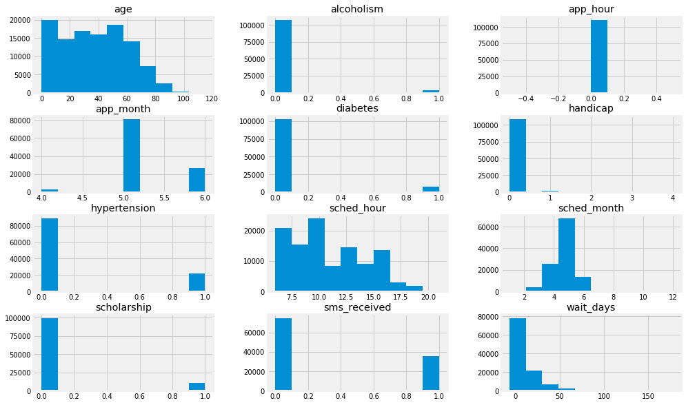

```python
df.hist(figsize=(15,10));
```

**so, I've summerized some informations:**

> Alcholism: non-alcoholic patients are the major

> Diabetes: most patients aren't diabetic

> Hypertension: the major are not hypertensive patients

> sms_recieved: most patients didn't get the sms messege ---**This means that no sms_recieving increases the possibilty of showing up**

> patient who are **not handicap** append

##### There is a problem, where wait_days are below 0 , but I won't drop it to not affect the rest of the data

**no_show** is type of object.... convert to boolean to make it easy with visualizations charts  
but first: check that they are all of the values of yes or no

```python
df['show'].value_counts()
```

```
No     88207
Yes    22319
Name: show, dtype: int64
```

```python
df['show'].replace({'No':1,'Yes':0},inplace=True)
df['show']=df['show'].astype('bool')
```

```python
df.info()
```

```
<class 'pandas.core.frame.DataFrame'>
Int64Index: 110526 entries, 0 to 110526
Data columns (total 18 columns):
patient_id        110526 non-null object
gender            110526 non-null object
age               110526 non-null int64
neighbourhood     110526 non-null object
scholarship       110526 non-null int64
hypertension      110526 non-null int64
diabetes          110526 non-null int64
alcoholism        110526 non-null int64
handicap          110526 non-null int64
sms_received      110526 non-null int64
show              110526 non-null bool
sched_month       110526 non-null int64
sched_hour        110526 non-null int64
sched_week_day    110526 non-null object
app_month         110526 non-null int64
app_week_day      110526 non-null object
app_hour          110526 non-null int64
wait_days         110526 non-null int64
dtypes: bool(1), int64(12), object(5)
memory usage: 15.3+ MB
```

## Exploratory Data Analysis

#### First let's know how many people attend the appointmnet day?

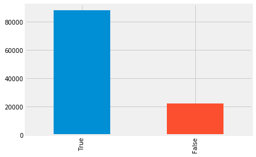

```python
df['show'].value_counts().plot(kind='bar');
```

```python
total=df['show'].count()
total
```

```
110526
```

```python
absence=df.query('show == 0')['show'].count()
absence
```

```
22319
```

```python
append=df.query('show == 1')['show'].count()
append
```

```
88207
```

```python
prop_true=append/total
prop_true
```

```
0.79806561352080052
```

```python
prop_false=absence/total
prop_false
```

```
0.20193438647919945
```

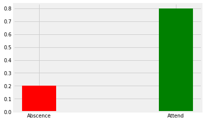

```python
plt.bar(['Abscence','Attend'],[prop_false,prop_true], width=0.25 , color=['red','green']);
```

### 1- Who is more abscent than the other: Hypertensive or non-hypertensive

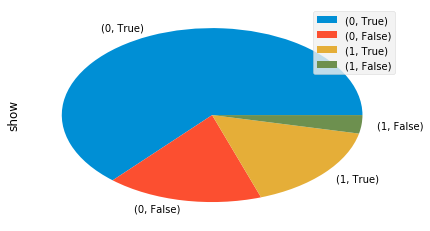

```python
df.groupby('hypertension')['show'].value_counts().plot(kind='pie')
plt.legend();
```

Here we can see that the majority who attended the appointment day are not hypertensive

But let's see it more obviously!

```python
show_count=df.groupby(['show','hypertension']).count()['patient_id']
show_count
```

```
show   hypertension
False  0               18547
       1                3772
True   0               70178
       1               18029
Name: patient_id, dtype: int64
```

```python
show_total=df.groupby('show').count()['patient_id']
show_total
```

```
show
False    22319
True     88207
Name: patient_id, dtype: int64
```

```python
show=show_count[1]/show_total[1]
show
```

```
hypertension
0    0.795606
1    0.204394
Name: patient_id, dtype: float64
```

```python
no_show=show_count[0]/show_total[0]
no_show
```

```
hypertension
0    0.830996
1    0.169004
Name: patient_id, dtype: float64
```

```python
ind =np.arange(len(show))
width = 0.1
```

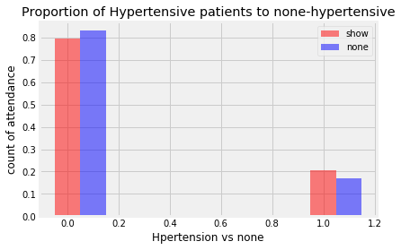

```python
show_bar= plt.bar(ind, show, width, alpha=0.5, color='r', label='show')
non_show_bar= plt.bar(ind+width, no_show, width, alpha=0.5,color='b',label='none')

plt.title('Proportion of Hypertensive patients to none-hypertensive')
plt.xlabel('Hpertension vs none')
plt.ylabel('count of attendance')
plt.legend();
```

## 2-How can sms messeges affect appointment shows?

## 3-How can gender affect appointment shows?

```python
df['IsMale'] = df['gender'].replace({'F': 0, 'M': 1})
```

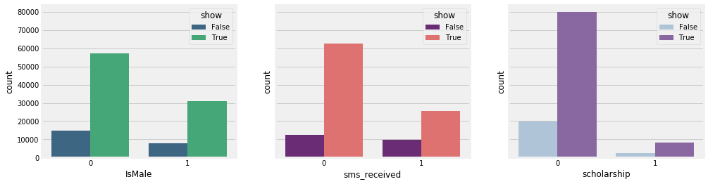

```python
fig, (ax1, ax2, ax3) = plt.subplots(ncols=3, sharey=True)
sns.countplot(x='IsMale', data=df, hue='show', ax=ax1, palette='viridis');
sns.countplot(x='sms_received', data=df, hue='show', ax=ax2, palette='magma');
sns.countplot(data=df,x='scholarship',hue='show',palette='BuPu', ax=ax3)
fig.set_figwidth(15)
fig.set_figheight(4)
```

#### I just figure it out : That **females** append more than males

#### people who didn't receive sms messeges append more than people who recieved sms

#### People with no scholarship attend more

### 4- Now, Which month of the year affect the show appointment?

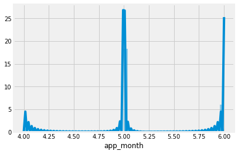

```python
sns.distplot(df.app_month);
```

### 5-What's the most popular age attended the show?

```
Text(0.5,1,'Age Distribution')
```

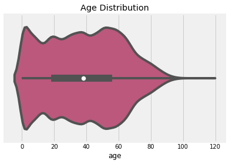

```python
sns.violinplot(x=df[df.show==1].age, palette='plasma');
plt.title("Age Distribution")
```

As we can see that most people are below 80's attend the appointment show

### 6-Can neighbourhood affect count of people showing up?

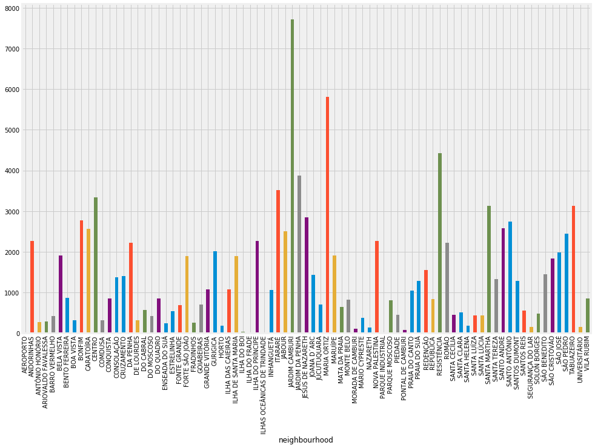

```python
df.groupby('neighbourhood').count()['show'].plot(kind='bar',figsize=(15,10));
```

I want to see if theremight be a correlation between independent variable

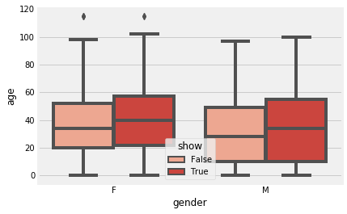

```python
sns.boxplot(x="gender",y="age", hue="show", data=df, palette="Reds");
```

### Limitations

**__ I couldn't drop waiting days that are less than zero, as it will affect the data badly

## Submitting your Project

```python
from subprocess import call
call(['python', '-m', 'nbconvert', 'Investigate_a_Dataset.ipynb'])
```